# Milestone report for data science capstone

Claus Gaarde Pedersen

5 jun 2016

# Exploratory analysis of data from [HC Corpora](http://www.corpora.heliohost.org/)

## Report

The purpose of this report is to make an exploratory analysis of data from HC Corpora, which will be used later in making an app, that by using an ngram model, can predict the next word in a sentence. For this study we will focus on examining the 3 datasets from the english part. The 3 parts, are blogs-, news- and twitter-documents.

#### Examining full length files

The first table below are stats extracted from the full files. The memorysize is well above the filesizes so apparantly the whole files are loaded in. The number of documents loaded in can be seen, and by comparing with the number of characters its clear that twitter contains the least characters per post, which is to be expected. The words per sentence is also the lowest for Twitter, with blogs and news about even, and that is also expected.

File stats

| file | filesize | memorysize | docs | chars | words | sentences |
| --- | --- | --- | --- | --- | --- | --- |
| blogs | 210160014 | 258205128 | 899288 | 206043906 | 37510168 | 2381035 |
| news | 205811889 | 260763944 | 1010242 | 202917604 | 34749301 | 2024367 |
| twitter | 167105338 | 315556832 | 2360148 | 161961555 | 30088605 | 3770622 |

#### Summary of words per document

Next we will look at the amount of words per document. For that a summary is made for each file, showing quantiles (what the 1/4 the ? and the 3/4 documents wordcount is) and what the min, mean and max wordcount is.  
The max wordcount for blogs and news show that there are some extreme cases with documents containing alot of words. In the case of blogs it also skews the mean up so its far away from the median. Twitter have a max character length restriction that limits the amount of words in an post, so its max is not high.

Summary per file

|  | Min. | 1st Qu. | Median | Mean | 3rd Qu. | Max. |
| --- | --- | --- | --- | --- | --- | --- |
| blogs | 0 | 9 | 28 | 41.71 | 60 | 6725 |
| news | 0 | 19 | 31 | 34.40 | 46 | 1796 |
| twitter | 1 | 7 | 12 | 12.75 | 18 | 47 |

#### Histogram of words per document

Next histograms for the 3 files will be shown. They are adjusted so they dont get effected by the outliers in blogs and news.  
Blogs have the largest concentration of documents with around 5 words, declines rapidly, short plataue from 20 to 40 words, declines slowly from there.  
Newshist slighty bell-shaped with largets concentration around 30 words/document, where the left-side has been ‘truncated’ up into a spike around 4 words.  
Twitterhist spike at 6 words slowly declining until 21 words, rapid decline after that.

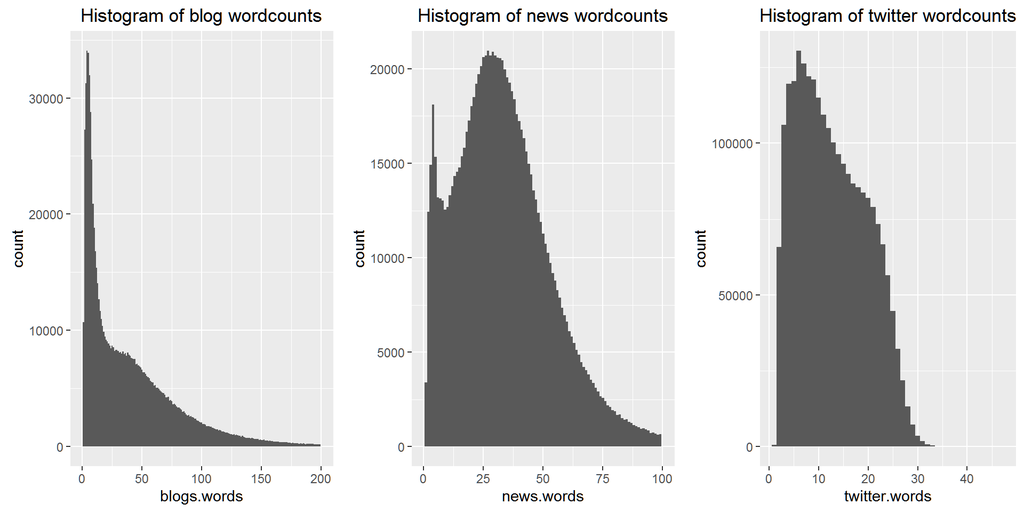

#### Assessment of the histograms

The goal of the final assignment is to make a prediction model of text input. For that it will be best to train on data that have good amount of normal sentences. The histograms shows that there is a large amount of blogs, with limited number of words. A further study could be to examine if these short blogs are much different than the other blogs. To keep this report brief, this study is moved to the Blog examination appendix (choose tab at the top)

#### Sampling

After the full file examination, we will continue by looking at what these documents contain, by starting some preliminary modelling. This part require a large degree of computational power so for efficiency only a smaller random sample from each file is used. In this study its 20 %.

#### Preliminary modelling

The modelling in this report will be done with the quanteda packages. By using this package, a corpus will be made. This is a structured set of text-documents, Which will be useable for further studying making a document feature matrix. This is a matrix that can tell how often a feature (here a word) occurs in each document. Doing those steps will allow us to take a first glimpse of whats in the documents, by presenting a wordcloud for each file. Normally wordclouds are being cleaned for stopwords - what we call the most common words in the language that normally dont have much meaning by themselves. They are usually removed, so the content words will be clearer to see. But thats not the purpose of our analysis, we want to see all words being used.

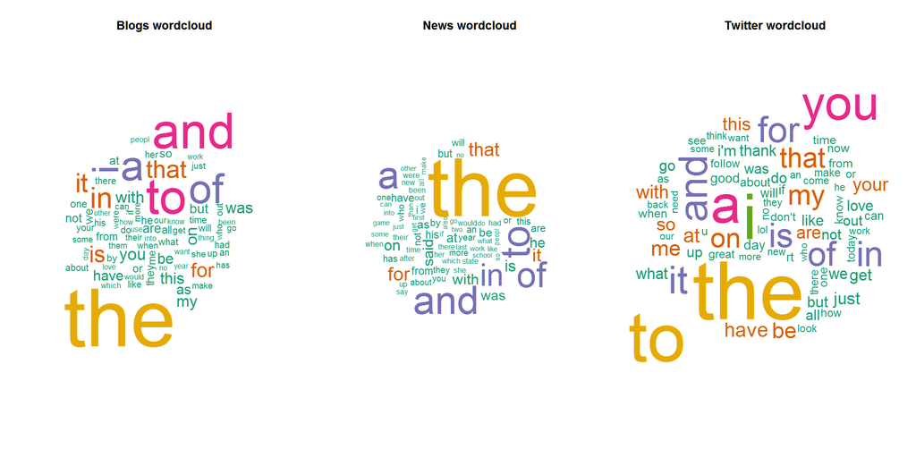

#### Analysis of wordclouds

The first impulse from the wordclouds is that blogs and news are quite similar, and twitter stands out as being different. ‘You’, ‘I’, ‘me’, ‘my’ is getting used much more in twitter. Except you in twitter the topmost common words is still about the same between the 3 file-types.  
As the final goal is to make a prediction model, this can suggest making different models for twitter and for the rest. But this also depends on how the sentences are built up, and for that we will go to the next step.

#### Sentences

In predicting the next word you use the knowledge of the prior words to have a guess of what the most common next usually is. To see how they are we will create the first step in doing so, by making bi-grams - what 2 words follow each other. The most common bigrams for blogs and twitter can be seen below.

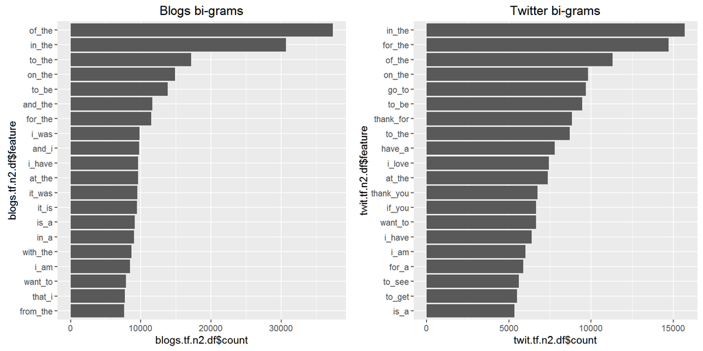

### Looking forward to the final assignment

I have to decide if i want to make a general model that tries to predict for all the 3 types of documents, or make a model that are more specialised to one type. If possible i would probably make a more specialised, even make 2 different models, if the final shiny app can handle it.  
Other thinks to include in the model, could be removing profanity. It shouldnt be something the model end up suggesting for the next word. Some common lists can be found on the web, and they can easily be removed like stopwords.  
Foreign words is another thing. According to HC Corpora, they have already been attempted to be removed, but there can still be some left. Probably have to incorporate dictionary to find the words that dosnt exists in the english language. Though thats stuff that has to be researched first.  
I also plan to make the shiny app have some swift-key functionality, in that not just the highest scoring next word will be shown, but the 3 highest scoring. It will feel better even when you are not predicting the right next word, that hopefully one of the other 2 is.

## Blogs examination

#### Study of blogs length effect on sentences

Blogs words ranking

| word | rank.5 | rank.10 | rank.large |
| --- | --- | --- | --- |
| the | 1 | 1 | 1 |
| and | 2 | 2 | 2 |
| to | 6 | 3 | 3 |
| i | 3 | 4 | 6 |
| a | 4 | 5 | 4 |
| of | 5 | 6 | 5 |
| in | 10 | 8 | 7 |
| it | 8 | 10 | 8 |
| you | 7 | 7 | 13 |
| is | 9 | 9 | 10 |
| for | 12 | 11 | 11 |
| that | 13 | 13 | 9 |
| my | 11 | 12 | 16 |
| this | 18 | 14 | 17 |
| with | 22 | 15 | 12 |
| on | 20 | 16 | 15 |
| are | 23 | 18 | 22 |
| me | 14 | 19 | 32 |
| be | 30 | 21 | 18 |
| was | 31 | 26 | 14 |

#### Analysis

The table above show the most common words for each group by its ranking with 1 being the most common. The 2 most common words ‘the’ and ‘and’ is the same across the groups, before the differences start to show. There is quite some difference between the 5 and large group when you get to the rankings from 10-20. The differences is not so clear just looking at the numbers in the table. My initial quess before starting the analysis is that blogs with low wordcount is more like twitter posts, and they dont necessary have to make a normally correct sentence. My assumption can maybe be indicated in the higher usage of you and me for the 5 group. The differences between each group is more clear when you look at the samples below.  
I cant make a clear conclusion but just a suggestion that if the prediction algorithm tries to be a general prediction where everything should be possible then everything should be used in the model. If the prediction model is focussed on making predictions for normal sentences in a blog, i would suggest removing the blogs with very low wordcount.

#### Sample documents of each blogs group

```
## [1] "Sample documents from blogs with 5 or less words :"
```

```
##  [1] "This is really exciting. Congratulations!"
##  [2] "Follow every rainbow,"
##  [3] "Even self-plagiarists."
##  [4] "Front 242 - Circling Overland"
##  [5] "Weiner Dogs Rule!"
##  [6] "So, things learned"
##  [7] "Sunday - Alpha"
##  [8] "5 took"
##  [9] "I am NOT a painter."
## [10] "Disc Nine (2008): Return"
## [11] "Model: VM605"
## [12] "A Rumour of God:"
## [13] "-BIG D O"
## [14] "and softly,"
## [15] "Walk into the light."
## [16] "\" Knit a sweater? No sweat!\""
## [17] "WOD for Tuesday 050112"
## [18] "\"No, it's really not.\""
## [19] "or soft buns"
## [20] "where words"
```

```
## [1] "Sample documents from blogs with 6 to 10 words :"
```

```
##  [1] "WONDERS OF DIVINITY: Sanctify Yourself copyright 2008 by Markus Brixius."
##  [2] "I winged out my liner on the lower lash line."
##  [3] "That skiffs your hearing till you notice it "
##  [4] "Search and Rescue (SAR) teams to the neighborhoods."
##  [5] "I wonder what it feels like to be a billionaire."
##  [6] "But finally I decided to just do it."
##  [7] "Out my window, my apple tree has gorgeous white blossoms."
##  [8] "Joe Braden: \"I don't want to talk about it.\""
##  [9] "I wonder how long this will last?"
## [10] "2 Kings 4: 1  7  The Widows Olive Oil"
## [11] "And how can I help you today, Gimme?"
## [12] "Well, the count is up to 4."
## [13] "add meat and onion to broth"
## [14] "Where is this Era of Responsibility you yak about?"
## [15] "Finding John Christmas ... Hallmark Channel ... 10 PM"
## [16] "1,2,3,4 1,2 thats the song of the Count"
## [17] "Just hoping that no one reads this."
## [18] "Known For: Being Director of Everything"
## [19] "\"There are, of course, entirely black forms of magic."
## [20] "I wanted him to poo, but it went bad"
```

```
## [1] "Sample documents from blogs with over 10 words :"
```

```
##  [1] "This is the famous variety selected by Mr Golding of East Malling from a garden of Canterbury Whitebines shortly before 1790 (2)."
##  [2] "Radar and gravity sensors have revealed details of Gamburtsev subglacial mountains, which was originally detected by Russian scientists 50 years ago at the heart of the East Antarctic ice sheet, Reuters reported."
##  [3] "I was getting tired and thinking that I really should make my way back to recognizable sights. I sat down on a rock that was right next to a tree. The rock was just the right height and the tree was perfect for leaning against. I dont know if I fell asleep or was just in that in between sta…
##  [4] "Kota Marudu MP, federal minister Maximus Ongkili has been unable to untangle the thorny issue."
##  [5] "He has also written, or created, one previous book, This Is For You, which concerned one man's search for a soulmate. His latest is described by Helena Bonham Carter on the back cover as 'a bedtime story for every age' and follows the fortunes of two birds who have a baby. The mother has an…
##  [6] "A final comment: An Australian said this (amazing wisdom!)  There are two main methods for keeping cattle on the ranch. One is to build a fence around the perimeter. The other is to dig a well in the centre of the property."
##  [7] "Brewed another batch of the coffee imperial porter. When I find out more about the event it was created for, I'll try to fill you in on the details. I'm strictly working through my \"agent\" at this point and didn't think to ask him more about it while we were brewing this afternoon. We wer…
##  [8] "Man, I am on a pencil kick. I swear my kids are eating them. They will all have enough pencils to get their math done BEFORE lunch, but right after lunch half of the class is missing their's. (They are only allowed one at a time right now, because they started hording pencils while I was ou…
##  [9] "Let me ask you  Have you ever fasted  why or why not? If you have fasted, have you ever had a spiritual breakthrough as a result of fasting? What comes to your mind when you think of fasting?"
## [10] "When we finally got on the road without any children in the backseat we breathed a sigh at the sound of quiet. We enjoyed a leisurely drive up to our destination about two hours north of where we live. We stopped for lunch. Got lost a couple times. Shopped at a goodwill we found along the w…
## [11] "Nevertheless, consultants within the business field spot few barriers that may hamper a company's efforts for a successful benchmark analysis. This happens when the aspects of core business processes, like quality, price, and reliability of the tip product or service created offered to the …
## [12] "He said the cabin was expensively furnished. Breathtakingly beautiful location and the cabin was state of the art made."
## [13] "If, like me, youve ever said you can eat chocolate every meal of every day, then this recipe for a Spicy Beef and Chocolate Casserole is something youll want to try. Yes, you read that right-- beef and chocolate cooked together! I know it sounds a crazy idea, but it works, as it has done fo…
## [14] "Currently on my mind: Jeeps! I always used to go on 'gas guzzling' tirades when I was younger and still don't dig the idea of wasting vast amounts of petrol for the purpose of car vanity but all of a sudden I really rather like jeeps. It's a combination of seeing nice battered black Wrangle…
## [15] "Damn it, no! the gravely voice barked cantankerously, Bring me an A-5312! How many times do I have to tell you, A-5312, not A-5315 you idiot!"
## [16] "The invitation is for REST. My favourite picture of rest is from the well-known Psalm 23:"
## [17] "Even after the arrival of French women, it was common for wealthy whites to keep mulatto mistresses. Still, the color line was well observed when it came to marriage. The few white men who married mulattos were shunned by white society and stripped of many rights-with the French governments…
## [18] "What theme will He weave in and out of every piece of my life?"
## [19] "I enjoy writing. I like sharing stories about my kids. Sharing humor, and hopefully helping other moms see that perfection is not necessary."
## [20] "Everything is unique about this mountain; The giant clay toned rocks that stand like over-sized sand drip castles; the on-going rolling waves of green that are every now and then met with thick streaks of red from the deep clay; and the Catalan tradition it holds to day."
```

## Code

For markdown code see https://github.com/clausgp/milestone

```r
# library & data setup

options(scipen=8)
library(readr)
library(stringi)
library(quanteda)
library(RColorBrewer)
library(ggplot2)
library(dplyr)
library(knitr)
library(gridExtra)

# the source dosnt specify encoding. Trying to use guess from readr packages
guess_encoding("final/en_US/en_US.blogs.txt")
guess_encoding("final/en_US/en_US.news.txt")
guess_encoding("final/en_US/en_US.twitter.txt")
# all guess UTF-8 with confidence 1

# using readlines to get character vectors
blogs.file <- readLines("final/en_US/en_US.blogs.txt", encoding="UTF-8")
# difficult characters in news.file so ahve to read as binary
tmp <- file("final/en_US/en_US.news.txt", open="rb")
news.file <- readLines(tmp, encoding="UTF-8")
close(tmp)
# some null values in twitter ... pun intended :-)
twitter.file <- readLines("final/en_US/en_US.twitter.txt", skipNul=TRUE, encoding="UTF-8")

# remove bad characters. using iconv, because i couldnt find the solution with stringi
blogs.file <- iconv(blogs.file, from="UTF-8", to="ASCII", sub="")
news.file <- iconv(news.file, from="UTF-8", to="ASCII", sub="")
twitter.file <- iconv(twitter.file, from="UTF-8", to="ASCII", sub="")
```

```r
# examining full length files

filenames <- c("blogs", "news", "twitter")
# file size
txt.file.size <- c(file.size("final/en_US/en_US.blogs.txt"),
                   file.size("final/en_US/en_US.news.txt"),
                   file.size("final/en_US/en_US.twitter.txt"))
# memory.size
txt.mem.size <- c(object.size(blogs.file), object.size(news.file), object.size(twitter.file))
# documents
txt.len <- c(length(blogs.file), length(news.file), length(twitter.file))
# chars
txt.chars <- c(sum(stri_count_boundaries(blogs.file, type="character")),
               sum(stri_count_boundaries(news.file, type="character")),
               sum(stri_count_boundaries(twitter.file, type="character")))
# words
blogs.words <- stri_count_words(blogs.file)
news.words <- stri_count_words(news.file)
twitter.words <- stri_count_words(twitter.file)
txt.words <- c(sum(blogs.words), sum(news.words), sum(twitter.words))
# sentences
txt.sent <- c(sum(stri_count_boundaries(blogs.file, type="sentence")),
              sum(stri_count_boundaries(news.file, type="sentence")),
              sum(stri_count_boundaries(twitter.file, type="sentence")))
# file stats
sum.txt.stats <- data.frame(file=filenames, filesize=txt.file.size, memorysize=txt.mem.size,
                            docs=txt.len, chars=txt.chars, words=txt.words,
                            sentences=txt.sent)
kable(sum.txt.stats, caption="File stats")
```

```r
# summary on words

summary.words <- rbind(summary(blogs.words), summary(news.words), summary(twitter.words))
row.names(summary.words) <- filenames
kable(summary.words, caption="Summary per file")
```

```r
# histograms

bplot <- qplot(blogs.words, geom="histogram", xlim=c(0,200), bins=201, main="Histogram of blog wordcounts")
nplot <- qplot(news.words, geom="histogram", xlim=c(0,100), bins=101, main="Histogram of news wordcounts")
tplot <- qplot(twitter.words, geom="histogram", bins=47, main="Histogram of twitter wordcounts")
grid.arrange(bplot, nplot, tplot, ncol=3)
```

```r
# Sampling setup

pct <- 0.2

set.seed(1234)
blogs <- sample(blogs.file, pct*length(blogs.file))
news <- sample(news.file, pct*length(news.file))
twitter <- sample(twitter.file, pct*length(twitter.file))

blogs.corp <- corpus(blogs)
news.corp <- corpus(news)
twitter.corp <- corpus(twitter)
```

```r
# Wordclouds - document feature matrix

# free some memory
rm(news.file, twitter.file)

# make document feature matrix with lowercasing, removed numbers, removed punctuation, removed whitespaces
# and stemmed.
# to have a meaningfull wordcloud, stopwords are also removed for 1-gram. For predicting they should not be removed
blogs.dfm <- dfm(blogs.corp, stem=TRUE, verbose=FALSE)
news.dfm <- dfm(news.corp, stem=TRUE, verbose=FALSE)
twitter.dfm <- dfm(twitter.corp, stem=TRUE, verbose=FALSE)

# wordcloud of most common words
par(mfrow = c(1, 3))
plot(blogs.dfm, max.words = 80, colors = brewer.pal(6, "Dark2"), scale = c(8, .5))
title("Blogs wordcloud")
plot(news.dfm, max.words = 80, colors = brewer.pal(6, "Dark2"), scale = c(8, .5))
title("News wordcloud")
plot(twitter.dfm, max.words = 80, colors = brewer.pal(6, "Dark2"), scale = c(8, .5))
title("Twitter wordcloud")
```

```r
# bigrams

# free some memory
rm(blogs.dfm, news.dfm, twitter.dfm)

blogs.dfm.n2 <- dfm(blogs.corp, stem=TRUE, ngrams=2, verbose=FALSE)
twitter.dfm.n2 <- dfm(twitter.corp, stem=TRUE, ngrams=2, verbose=FALSE)

# generate barplot of most common blogs bigrams
blogs.tf.n2 <- topfeatures(blogs.dfm.n2, 20)
blogs.tf.n2.df <- data.frame(feature=names(blogs.tf.n2), count=blogs.tf.n2, row.names=NULL)
blogs.tf.n2.df$feature <- factor(blogs.tf.n2.df$feature, levels=rev(blogs.tf.n2.df$feature))
bn2.plot <- ggplot(blogs.tf.n2.df, aes(blogs.tf.n2.df$feature, blogs.tf.n2.df$count)) +
    geom_bar(stat="identity") + coord_flip() + ggtitle("Blogs bi-grams")

# generate barplot of most common twitter bigrams
twit.tf.n2 <- topfeatures(twitter.dfm.n2, 20)
twit.tf.n2.df <- data.frame(feature=names(twit.tf.n2), count=twit.tf.n2, row.names=NULL)
twit.tf.n2.df$feature <- factor(twit.tf.n2.df$feature, levels=rev(twit.tf.n2.df$feature))
tn2.plot <- ggplot(twit.tf.n2.df, aes(twit.tf.n2.df$feature, twit.tf.n2.df$count)) +
    geom_bar(stat="identity") + coord_flip() + ggtitle("Twitter bi-grams")
grid.arrange(bn2.plot, tn2.plot, ncol=2)
```

```r
# Blogs examination

# sampling in groups of wordcounts <=5, 6-10 and >10. Keeping the sample size (number of docs) even for each group.
pct <- 0.1
sampl.size <- pct*length(blogs.file)

set.seed(1234)
blogsl.file <- blogs.file[stri_count_words(blogs.file)>10]
blogsl <- sample(blogsl.file, sampl.size)
blogs.file5 <- blogs.file[stri_count_words(blogs.file)<=5]
blogs5 <- sample(blogs.file5, sampl.size)
blogs.file10 <- blogs.file[stri_count_words(blogs.file)<=10 & stri_count_words(blogs.file)>5]
blogs10 <- sample(blogs.file10, sampl.size)

# corpus
blogsl.corp <- corpus(blogsl)
blogs5.corp <- corpus(blogs5)
blogs10.corp <- corpus(blogs10)

# document feature matrix
blogsl.dfm <- dfm(blogsl.corp, stem=TRUE, verbose=FALSE)
blogs5.dfm <- dfm(blogs5.corp, stem=TRUE, verbose=FALSE)
blogs10.dfm <- dfm(blogs10.corp, stem=TRUE, verbose=FALSE)

# most common words
blogsl.top <- topfeatures(blogsl.dfm, 200)
blogs5.top <- topfeatures(blogs5.dfm, 200)
blogs10.top <- topfeatures(blogs10.dfm, 200)
blogsl.top.df <- data.frame(word=attributes(blogsl.top)$names, count.large=blogsl.top, stringsAsFactors=FALSE)
blogsl.top.df$rank.large <- 1:200
blogs5.top.df <- data.frame(word=attributes(blogs5.top)$names, count.5=blogs5.top, stringsAsFactors=FALSE)
blogs5.top.df$rank.5 <- 1:200
blogs10.top.df <- data.frame(word=attributes(blogs10.top)$names, count.10=blogs10.top, stringsAsFactors=FALSE)
blogs10.top.df$rank.10 <- 1:200
blogs.df <- blogs5.top.df %>% full_join(blogs10.top.df) %>% full_join(blogsl.top.df)
blogs.df$rank.sum <- blogs.df$rank.5 + blogs.df$rank.10 + blogs.df$rank.large
blogs.df <- arrange(blogs.df, rank.sum) %>% select(word, rank.5, rank.10, rank.large)
kable(head(blogs.df, 20), caption="Blogs words ranking")
```

```r
# Blogs samples

print("Sample documents from blogs with 5 or less words :")
blogs5[100:119]
print("Sample documents from blogs with 6 to 10 words :")
blogs10[100:119]
print("Sample documents from blogs with over 10 words :")
blogsl[100:119]
```